# Practical D

Jolien Cremers

Statistical Programming with R

The purpose of this practical is to use some of R’s packages to solve a missing data problem by imputing missing values in a ‘real’ dataset. This can either be a dataset you’ve brought to this course yourself or the `selfreport` data from the `mice` package. The ‘selfreport’ data is described in Section 7.3 of the first edition of the book Flexible Imputation of Missing Data (van Buuren, S. (2012). *Flexible Imputation of Missing Data.* CRC/Chapman & Hall, FL: Boca Raton).

Suggested packages:

```r
library(naniar) # additional package for practical
library(simputation) # common interface for several imputation methods
library(tidyverse)
```

**Note that:** A potential issue is that some of the functions in `simputation` and `naniar` have the same names - e.g. `impute_median`. This means that the order in which the packages are loaded matters - the last loaded package masks the functions from the former package. To specify which package you mean, call `simputation::impute_median` and `naniar::impute_median`

#### Selfreport data

```r
selfreport <- mice::selfreport
```

The selfreport data contains data from two studies, one from the `mgg` study, the *survey dataset*, where height and weight are selfreported measures (`hr` and `wr`) and one from the `krul` study, the *calibration dataset*, where the height and weight measures are both selfreported and measured (variables `hm` and `wm`). The goal for the self-report data is to obtain correct estimates of the prevalence of obesity (Body Mass Index > 32) in the *survey dataset*. Note that the Body Mass Index (bmi) is computed as follows:

$$\text{bmi} = \frac{\text{weight in kg}}{(\text{height in m})^2}$$

1. **Check missing data patterns.**

First, check if there is a description of the `selfreport` data in the `mice` package documentation:

```r
?selfreport
```

```
## starting httpd help server ... done
```

The selfreport data contains data from two studies, one from the `mgg` study where height and weight are selfreported measures (`hr` and `wr`) and one from the `krul` study where the measures are both selfreported and measured (variables `hm` and `wm`).

Then, investigate the missing data patterns

```r
head(selfreport, n = 10)
```

```
##    src    id pop age    sex hm wm  hr  wr          prg    edu        etn web bm
## 1  mgg 10001  NL  27   Male NA NA 190  85         <NA> Middle Autochtone  No NA
## 2  mgg 10002  NL  38   Male NA NA 189  93         <NA>    Low Autochtone  No NA
## 3  mgg 10003  NL  21   Male NA NA 200 110         <NA>    Low Autochtone  No NA
## 4  mgg 10004  NL  52   Male NA NA 176  80         <NA>    Low Autochtone  No NA
## 5  mgg 10005  NL  44   Male NA NA 183  79         <NA> Middle Autochtone  No NA
## 6  mgg 10006  NL  31 Female NA NA 167  80 Not pregnant Middle Autochtone  No NA
## 7  mgg 10007  NL  42 Female NA NA 187  73 Not pregnant   High Autochtone  No NA
## 8  mgg 10008  NL  39   Male NA NA 180  85         <NA>   High Allochtone  No NA
## 9  mgg 10009  NL  36 Female NA NA 178  70 Not pregnant Middle Autochtone  No NA
## 10 mgg 10010  NL  38 Female NA NA 174  55 Not pregnant   High Allochtone  No NA
##          br
## 1  23.54571
## 2  26.03511
## 3  27.50000
## 4  25.82645
## 5  23.58984
## 6  28.68514
## 7  20.87563
## 8  26.23457
## 9  22.09317
## 10 18.16620
```

```r
summary(selfreport)
```

```
##    src             id        pop            age            sex
##  krul:1257   Min.   :10001   NL:2060   Min.   :18.00   Female:1098
##  mgg : 803   1st Qu.:10612   IT:   0   1st Qu.:29.00   Male  : 962
##              Median :12302   US:   0   Median :41.00
##              Mean   :13299             Mean   :42.06
##              3rd Qu.:15958             3rd Qu.:54.00
##              Max.   :17079             Max.   :75.00
##
##        hm              wm              hr              wr
##  Min.   :143.6   Min.   : 44.0   Min.   :143.0   Min.   : 30.00
##  1st Qu.:166.5   1st Qu.: 66.0   1st Qu.:168.0   1st Qu.: 66.00
##  Median :173.3   Median : 75.8   Median :175.0   Median : 75.20
##  Mean   :174.0   Mean   : 77.8   Mean   :174.9   Mean   : 77.79
##  3rd Qu.:181.1   3rd Qu.: 86.6   3rd Qu.:182.0   3rd Qu.: 87.00
##  Max.   :207.3   Max.   :149.7   Max.   :214.0   Max.   :165.00
##  NA's   :803     NA's   :803
##                      prg           edu               etn        web
##  Pregnant              :   0   Low   : 286   Autochtone: 657   No :1858
##  Delivery last 6 months:   0   Middle: 323   Allochtone: 146   Yes: 202
##  Not pregnant          : 403   High  : 194   Unknown   :   0
##  NA's                  :1657   NA's  :1257   NA's      :1257
##
##
##
##        bm              br
##  Min.   :16.83   Min.   :10.76
##  1st Qu.:21.98   1st Qu.:22.08
##  Median :24.64   Median :24.71
##  Mean   :25.68   Mean   :25.39
##  3rd Qu.:28.12   3rd Qu.:27.67
##  Max.   :55.17   Max.   :52.08
##  NA's   :803
```

The measures weight and height variables are indeed missing from the `mgg` study

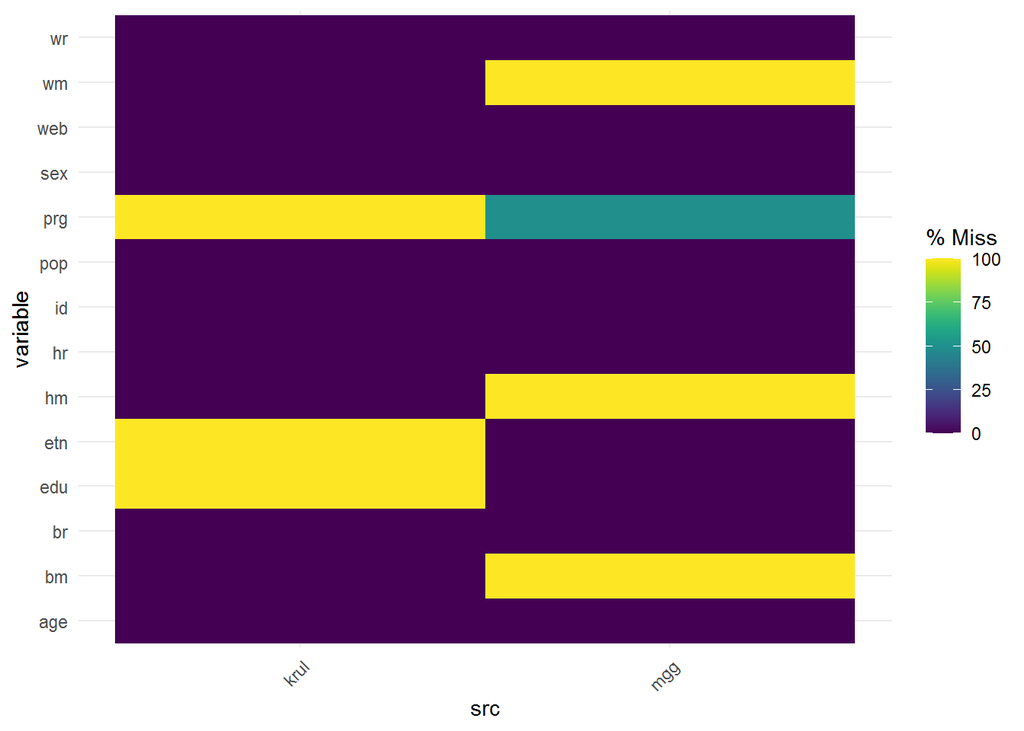

```r
gg_miss_fct(selfreport, src)
```

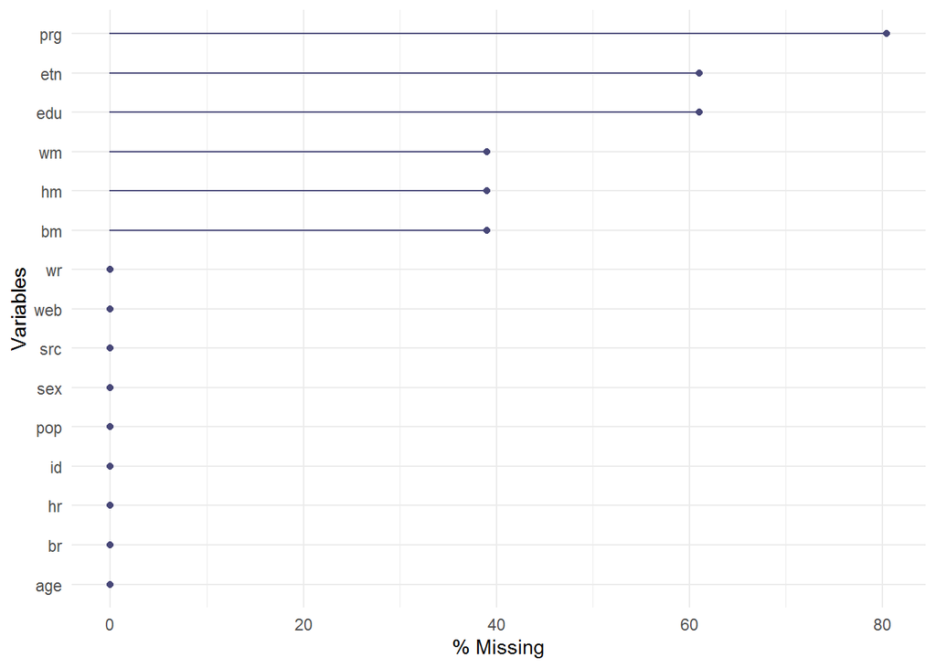

```r
gg_miss_var(selfreport, show_pct = TRUE)
```

Apart from measured height and weight also the measured bmi, the indicators for pregnancy, educational level and ethnicity contain missing values.

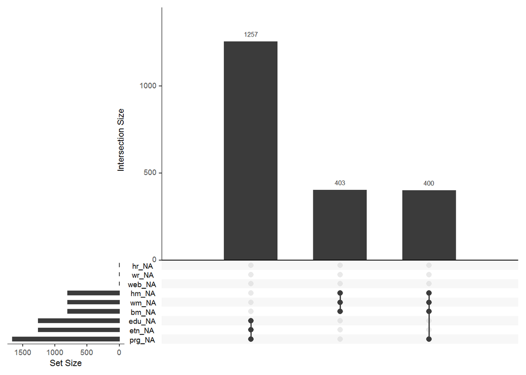

```r
gg_miss_upset(selfreport, nsets = 15)
```

2. **Check the relation between measured and self reported bmi in the *calibration dataset*.**

There are more individuals that have a lower selfreported BMI than measured BMI.

```r
calibration <- selfreport %>%
  filter(as.numeric(src) == 1) %>%
  mutate(difference = case_when(br < bm ~ "lower",
                                bm < br ~ "higher",
                                bm == br ~ "same"))

calibration %>% count(difference)
```

```
##   difference   n
## 1     higher 346
## 2      lower 910
## 3       same   1
```

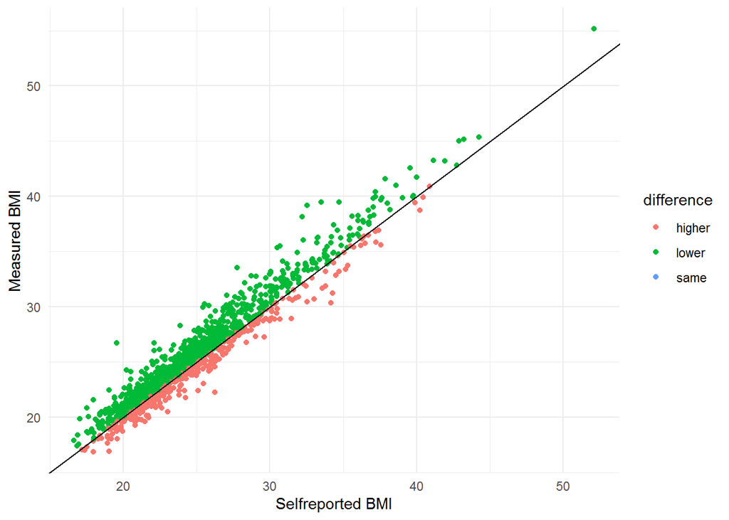

```r
ggplot(calibration, aes(br, bm, color = difference)) +
  geom_point() +
  theme_minimal() +
  geom_abline(intercept = 0, slope = 1) +
  labs(x = "Selfreported BMI", y = "Measured BMI", fill = "")
```

3. **Impute missing data using the simputation package - try, for instance impute_rf**

First define a deterministic function to compute bmi:

```r
bmi <- function(h, w) {
  return(w/(h/100)^2)
}
```

One approach could be `impute_rf` which implements a random forest to do the imputation

```r
# Impute prg
selfreport %>% count(sex, prg)
```

```
##      sex          prg   n
## 1 Female Not pregnant 403
## 2 Female         <NA> 695
## 3   Male         <NA> 962
```

```r
# We assume that missingness of prg implies "not pregnant"
selfreport <- selfreport %>%
  mutate( prg = replace_na( as.character(prg), "not pregnant")
        , prg = as.factor(prg)) %>%
  # The factor etn has missing levels that will cause trouble
  mutate( etn = droplevels(etn))

# First impute measured height and weight
library(randomForest)
selfreport_imp_rf <- impute_rf( selfreport,
                                formula = hm + wm ~ hr + wr + web  + src
                                              + age + sex + prg)

# Compute imputed bmi from imputed height and weight
selfreport_imp_rf <- selfreport_imp_rf %>%
  mutate( bm = bmi(hm,wm))
head(selfreport)
```

```
##   src    id pop age    sex hm wm  hr  wr          prg    edu        etn web bm
## 1 mgg 10001  NL  27   Male NA NA 190  85 not pregnant Middle Autochtone  No NA
## 2 mgg 10002  NL  38   Male NA NA 189  93 not pregnant    Low Autochtone  No NA
## 3 mgg 10003  NL  21   Male NA NA 200 110 not pregnant    Low Autochtone  No NA
## 4 mgg 10004  NL  52   Male NA NA 176  80 not pregnant    Low Autochtone  No NA
## 5 mgg 10005  NL  44   Male NA NA 183  79 not pregnant Middle Autochtone  No NA
## 6 mgg 10006  NL  31 Female NA NA 167  80 Not pregnant Middle Autochtone  No NA
##         br
## 1 23.54571
## 2 26.03511
## 3 27.50000
## 4 25.82645
## 5 23.58984
## 6 28.68514
```

```r
head(selfreport_imp_rf)
```

```
##   src    id pop age    sex       hm       wm  hr  wr          prg    edu
## 1 mgg 10001  NL  27   Male 184.4476 84.93727 190  85 not pregnant Middle
## 2 mgg 10002  NL  38   Male 183.6551 89.23774 189  93 not pregnant    Low
## 3 mgg 10003  NL  21   Male 188.4861 94.29685 200 110 not pregnant    Low
## 4 mgg 10004  NL  52   Male 175.3646 79.43421 176  80 not pregnant    Low
## 5 mgg 10005  NL  44   Male 180.5449 79.31581 183  79 not pregnant Middle
## 6 mgg 10006  NL  31 Female 168.9367 76.92825 167  80 Not pregnant Middle
##          etn web       bm       br
## 1 Autochtone  No 24.96618 23.54571
## 2 Autochtone  No 26.45712 26.03511
## 3 Autochtone  No 26.54230 27.50000
## 4 Autochtone  No 25.82995 25.82645
## 5 Autochtone  No 24.33266 23.58984
## 6 Autochtone  No 26.95491 28.68514
```

```r
# Impute edu and eth
selfreport_imp_rf <- impute_rf( selfreport_imp_rf,
                                formula = edu + etn ~ hr + wr + hm + wm + bm + br
                                          + web + src + age + sex + prg)

tail(selfreport)
```

```
##       src    id pop age    sex    hm   wm  hr wr          prg  edu  etn web
## 5201 krul 17073  NL  23   Male 179.8 83.1 180 81 not pregnant <NA> <NA>  No
## 5202 krul 17074  NL  27   Male 180.4 66.3 180 65 not pregnant <NA> <NA>  No
## 5203 krul 17076  NL  32 Female 166.0 81.0 160 78 not pregnant <NA> <NA>  No
## 5204 krul 17077  NL  20   Male 192.3 81.5 193 83 not pregnant <NA> <NA>  No
## 5205 krul 17078  NL  32 Female 161.3 76.4 162 77 not pregnant <NA> <NA>  No
## 5206 krul 17079  NL  28   Male 180.1 70.0 180 72 not pregnant <NA> <NA>  No
##            bm       br
## 5201 25.70524 25.00000
## 5202 20.37232 20.06173
## 5203 29.39469 30.46875
## 5204 22.03936 22.28248
## 5205 29.36464 29.34004
## 5206 21.58095 22.22222
```

```r
tail(selfreport_imp_rf)
```

```
##       src    id pop age    sex    hm   wm  hr wr          prg    edu        etn
## 5201 krul 17073  NL  23   Male 179.8 83.1 180 81 not pregnant Middle Autochtone
## 5202 krul 17074  NL  27   Male 180.4 66.3 180 65 not pregnant Middle Autochtone
## 5203 krul 17076  NL  32 Female 166.0 81.0 160 78 not pregnant    Low Autochtone
## 5204 krul 17077  NL  20   Male 192.3 81.5 193 83 not pregnant Middle Autochtone
## 5205 krul 17078  NL  32 Female 161.3 76.4 162 77 not pregnant    Low Allochtone
## 5206 krul 17079  NL  28   Male 180.1 70.0 180 72 not pregnant   High Allochtone
##      web       bm       br
## 5201  No 25.70524 25.00000
## 5202  No 20.37232 20.06173
## 5203  No 29.39469 30.46875
## 5204  No 22.03936 22.28248
## 5205  No 29.36464 29.34004
## 5206  No 21.58095 22.22222
```

```r
any_miss(selfreport_imp_rf)
```

```
## [1] FALSE
```

Estimated prevalence in the selfreported data

```r
selfreport_imp_rf %>%
  filter( src == "krul") %>%
  mutate(bm = bmi(hm, wm)) %>%
  mutate(obese = case_when(br > 32 ~ 1,
                           TRUE ~ 0)) %>%
  mutate(age_cat = cut(age, c(17, 29, 39, 49, 59, 75))) %>%
  group_by(src, sex, age_cat) %>%
  summarise(N = n(), prevalence = sum(obese)/N*100)
```

```
## # A tibble: 10 x 5
## # Groups:   src, sex [2]
##    src   sex    age_cat     N prevalence
##    <fct> <fct>  <fct>   <int>      <dbl>
##  1 krul  Female (17,29]   211      3.79
##  2 krul  Female (29,39]   160      8.12
##  3 krul  Female (39,49]   150     11.3
##  4 krul  Female (49,59]   137     19.0
##  5 krul  Female (59,75]    37     27.0
##  6 krul  Male   (17,29]   183      0.546
##  7 krul  Male   (29,39]   114      8.77
##  8 krul  Male   (39,49]   121      8.26
##  9 krul  Male   (49,59]   110     13.6
## 10 krul  Male   (59,75]    34      5.88
```

```r
selfreport_imp_rf %>%
  filter(src=="mgg") %>%
  mutate(bm = bmi(hm, wm)) %>%
  mutate(obese = case_when(br > 32 ~ 1,
                           TRUE ~ 0)) %>%
  mutate(age_cat = cut(age, c(17, 29, 39, 49, 59, 75))) %>%
  group_by(src, sex, age_cat) %>%
  summarise(N = n(), prevalence = sum(obese)/N*100)
```

```
## # A tibble: 10 x 5
## # Groups:   src, sex [2]
##    src   sex    age_cat     N prevalence
##    <fct> <fct>  <fct>   <int>      <dbl>
##  1 mgg   Female (17,29]    68      10.3
##  2 mgg   Female (29,39]    69      14.5
##  3 mgg   Female (39,49]    68      13.2
##  4 mgg   Female (49,59]    81      17.3
##  5 mgg   Female (59,75]   117       4.27
##  6 mgg   Male   (17,29]    69       1.45
##  7 mgg   Male   (29,39]    73       5.48
##  8 mgg   Male   (39,49]    66       4.55
##  9 mgg   Male   (49,59]    91      12.1
## 10 mgg   Male   (59,75]   101       1.98
```

End of practical.